# 03_exercise_01

## 1.Nhập / Xuất ,biểu thức toán học.

### Bài 1. Tính giá trị hàm số

**Yêu cầu**: Hãy viết chương trình nhập vào số thực x và tính giá trị biểu thức: $$ f\left(x\right) = x + \frac{x^5}{5!} + \frac{\sqrt{|x|}}{x^{3/2}} $$

> Moi ban nhap vao gia tri cua bien so x: **2.3**  
> Gia tri cua ham so f(**2.3**) = **3.27**.

#### Bài làm:

```python
# Khai báo thư viện
import math

# Nhập dữ liệu
x   = float(input('Moi ban nhap vao gia tri cua bien so x: '))
# Xử lý
f_x = x + (x**5)/math.factorial(5)  + math.sqrt(abs(x))/x**(3/2)

# Xuất dữ liệu
print(f'Gia tri cua ham so f({x}) = {f_x: .2f}.')
```

```
Gia tri cua ham so f(2.3) =  3.27.
```

### Bài 2. Đổi sang giờ phút giây

**Yêu cầu**: Một thiết bị hoạt động được t giây. Hãy viết chương trình chuyển số giây đó dưới dạng số giờ, số phút và số giây.

> Nhap vao tong so giay: **4810**  
> **4810** giay co dang **1:20:10**

#### Bài làm:

```python
# Nhập dữ liệu
t  = int(input('Nhap vao tong so giay: '))

# Xử lý
hh = t//3600
mm = (t % 3600) // 60
ss = t % 60

# Xuất dữ liệu
print(f'{t} giay co dang {hh}:{mm}:{ss}')
```

```
4810 giay co dang 1:20:10
```

## 2. Cấu trúc lựa chọn

### Bài 3. Giải phuơng trình bậc 1

Nhập 2 số thực $a$, $b$. Tìm nghiệm của phương trình bậc 1 $ax + b = 0$.

> Moi ban nhap he so a: **1**  
> Moi ban nhap he so b: **5**  
> Phuong trinh **1x + 5 = 0** co **1** nghiem x = **-5.00**.

#### Bài làm :

```python
# Nhập dữ liệu
a  = int(input('Moi ban nhap he so a: '))
b  = int(input('Moi ban nhap he so b: '))

# Xử lý
flag = -100
x=0
if a == 0 and b != 0:
    flag = 0
elif a == 0 and b == 0:
    flag = -1
else:
    x = -b /a
# Xuất dữ liệu
s = f'Phuong trinh {a}x + {b} = 0'
if flag == -1:
    print(f'{s} vo so nghiem.')
elif flag == 0:
    print(f'{s} vo nghiem.')
else:
    print(f'{s} co 1 nghiem x = {x: .2f}.')
```

```
Phuong trinh 1x + 5 = 0 co 1 nghiem x = -5.00.
```

### Bài 4. Chuyển ký số sang số

Nhập một chuỗi s là chuỗi biểu diễn ký tự số trong tiếng Anh gồm {zero, one, two, three, four, five, six, seven, eight, nine}. Hãy kiểm tra chuỗi nhập có hợp lệ không? Nếu hợp lệ thì in ra ký số của chuỗi đó và chuỗi ký số bên tiếng việt tương ứng.

> Moi ban nhap chuoi ky so s: One  
> Chuoi vua nhap hop le! "One" bieu dien so cho "1" va ung voi tieng Viet "mot".

> Moi ban nhap chuoi ky so s: hello  
> Chuoi vua nhap khong hop le!

#### Bài làm:

```python
s = input("Moi ban nhap chuoi ky so s: ")

en  = ["zero", "one", "two", "three", "four", "five", "six", "seven", "eight", "nine"]
vi  = ["khong", "mot", "hai", "ba", "bon", "nam", "sau", "bay", "tam", "chin"]
num = [0, 1, 2, 3, 4, 5, 6, 7, 8, 9]
#xử lí
s_lower = s.lower()
if s_lower in en:
    idx = en.index(s_lower)
    print(f'Chuoi vua nhap hop le! "{s}" bieu dien so cho "{num[idx]}" va ung voi tieng Viet "{vi[idx]}".')
else:
    print("Chuoi vua nhap khong hop le!")
```

```
Chuoi vua nhap khong hop le!
```

## 3. Cấu trúc lặp

### Bài 5. Tính tổng các số chẵn

Nhập một số nguyên n. Hãy tính tổng các số chẵn từ 1 đến n.

> Moi ban nhap so nguyen n: **100**  
> Tong cac so chan tu 1 den **100** la **2550**.

#### Bài làm:

```python
# Nhập dữ liệu
n   = int(input("Moi ban nhap so nguyen n: "))

# Xuất dữ liệu
s   = 0
#xử lí
for i in range(n+1):
    if i % 2 == 0:
        s+=i

print(f'Tong cac so chan tu 1 den {n} la {s}.')
```

```
Tong cac so chan tu 1 den 100 la 2550.
```

### Bài 6. Kiểm tra số nguyên tố

Nhập vào một số nguyên dương n. Hãy kiểm tra xem n có phải là nguyên tố không?

> Moi nhap nhap so nguyen n: **10**  
> **10** khong phai la so nguyen to.

> Moi nhap nhap so nguyen n: **97**  
> **97** la so nguyen to.

**Lưu ý**: n là số nguyên tố khi và chỉ khi không tồn tại số nguyên từ $2$ đến $\sqrt(n)$ mà chia hết cho n.

#### Bài làm:

```python
# Nhập dữ liệu
n   = int(input("Moi ban nhap so nguyen n: "))

# Xử lý
lant = True
for i in range(2,int(math.sqrt(n)+1)):
    if n % i == 0:
        lant= False
        break
# Xuất dữ liệu
if lant == True:
    print(f'{n} la so nguyen to.')
else:
    print(f'{n} khong la so nguyen to.')
```

```
97 la so nguyen to.
```

## 4. Xử lý ngoại lệ và hàm số

### Bài 7. Giải phương trình bậc 2

Nhập 3 số thực a, b, c (có kiểm tra dữ liệu nhập số thực). Hãy xây dựng hàm giải phương trình bậc 2 $ax^2+bx+c=0$ và in kết quả giải ra màn hình.

> Moi ban nhap he so a, b, c: **a b c**  
> Ban nhap sai! Moi ban nhap lai!  
> Moi ban nhap he so a, b, c: **1 a 3**  
> Ban nhap sai! Moi ban nhap lai!  
> Moi ban nhap he so a, b, c: **1 5 6**  
> Phuong trinh bac 2 **1x^2 + 5x + 6 = 0** co **2** nghiem x1 = **-2.00**, x2 = **-3.00**.

#### Bài làm:

```python
def NhapDuLieu():
    """
    Input:
        Ban phim = 1 5 6
    Output:
        (a, b, c) --> (1, 5, 6)
    """
    #Xử lí
    while True:
        try:
            a,b,c = map(int, input("Moi ban nhap he so a b c :").split())
            return a, b, c
        except ValueError:
            print("Ban nhap sai! Moi ban nhap lai!")

# NhapDuLieu
a, b, c = NhapDuLieu()
print(a,b,c)
```

```
Ban nhap sai! Moi ban nhap lai!
```

```
Ban nhap sai! Moi ban nhap lai!
```

```
1 5 7
```

```python
def GiaiPhuongTrinhBac2(a, b, c):
    """
    Input: a, b, c
    Output:
    + flag = -1 (VSN), 0 (VN), k (k nghiem)
    + () --> flag = -1, 0
    + (x,) --> flag = 1
    + (x1, x2) --> flag = 2
    """
    import math
    flag = None
    x = ()
    if a == 0:
        if b == 0:
            if c == 0:
                flag = -1  # vô số nghiệm
                x = ()
            else:
                flag = 0   # vô nghiệm
                x = ()
        else:
            flag = 1  # nghiệm duy nhất
            x = (-c / b,)
    else:
        # Tính delta
        delta = b**2 - 4*a*c
        if delta < 0:
            flag = 0  # vô nghiệm
            x = ()
        elif delta == 0:
            flag = 1  # nghiệm kép
            x = (-b / (2*a),)
        else:
            flag = 2  # 2 nghiệm phân biệt
            x1 = (-b - math.sqrt(delta)) / (2*a)
            x2 = (-b + math.sqrt(delta)) / (2*a)
            x = (x1, x2)

    return flag, x
```

```python
print("a = 0")
flag, x = GiaiPhuongTrinhBac2(0, 0, 0)
print(f'So nghiem: {flag}, nghiem = {x}')
flag, x = GiaiPhuongTrinhBac2(0, 0, 5)
print(f'So nghiem: {flag}, nghiem = {x}')
flag, x = GiaiPhuongTrinhBac2(0, 5, 6)
print(f'So nghiem: {flag}, nghiem = {x}')

print("a <> 0")
flag, x = GiaiPhuongTrinhBac2(5, 1, 2)
print(f'So nghiem: {flag}, nghiem = {x}')
flag, x = GiaiPhuongTrinhBac2(1, 2, 1)
print(f'So nghiem: {flag}, nghiem = {x}')
flag, x = GiaiPhuongTrinhBac2(1, 5, 6)
print(f'So nghiem: {flag}, nghiem = {x}')
```

```
a = 0
So nghiem: -1, nghiem = ()
So nghiem: 0, nghiem = ()
So nghiem: 1, nghiem = (-1.2,)
a <> 0
So nghiem: 0, nghiem = ()
So nghiem: 1, nghiem = (-1.0,)
So nghiem: 2, nghiem = (-3.0, -2.0)
```

```python
# Kết nối bài
a, b, c = NhapDuLieu()
# Gọi hàm giải
flag, x = GiaiPhuongTrinhBac2(1, 5, 6)
# Xuất dữ liệu
s = f'Phuong trinh bac 2 {a}x^2 + {b}x + {c} = 0'
if flag == -1:
    print(f'{s} co vo so nghiem!')
elif flag == 0:
    print(f'{s} vo nghiem!')
elif flag == 1:
    print(f'{s} co 1 nghiem, x = {x[0]}!')
elif flag == 2:
    print(f'{s} co 2 nghiem, x1 = {x[0]}, x2 = {x[1]}!')
```

```
Phuong trinh bac 2 1x^2 + 5x + 6 = 0 co 2 nghiem, x1 = -3.0, x2 = -2.0!
```

## 5. Dữ liệu nâng cao (List, Tuple, Set, Dictionary)

### Bài 8. Các thao tác xử lý mảng số

Viết chương trình xây dựng các hàm sau cho List và kiểm tra tính đúng đắn của các hàm số:

- Nhập một mảng số từ bàn phím cách nhau bởi khoảng trắng. Xuất mảng ra màn hình.
- Sinh một mảng số ngẫu nhiên có n phần tử trong khoảng a, b.
- Tính tổng của mảng số, đếm các phần tử chẵn, lẻ trong mảng.
- Cho một mảng số, hãy trả về dãy chẳn, dãy lẻ.

> a = NhapMang()  
> XuatMang(a)  
> b = SinhNgauNhien(10, -10, 10)  
> XuatMang(b)  
> tong, chan, le = TinhTongChanLe(b)  
> a_chan, a_le = TimChanLe(b)

#### Bài làm :

```python
def NhapMang():
    """
    Input:
        Ban phim = 1 4 1 2 3 4 1 2 3 3 1 2 3 4 10 2
    Output:
        a = [1, 4, 1, 2, 3, 4, 1, 2, 3, 3, 1, 2, 3, 4, 10, 2]
    """
    # Xử lí
    s=input("Mời bạn nhập mảng (cách nhau khoảng trắng) = ")
    a=list(map(int,s.split()))


    return a
```

```python
# NhapMang
a = NhapMang() # 1 4 1 2 3 4 1 2 3 3 1 2 3 4 10 2
print(a)
```

```
[1, 4, 1, 2, 3, 4, 1, 2, 3, 3, 1, 2, 3, 4, 10, 2]
```

```python
def XuatMang(a):
    """
    Input:
        a = [1, 4, 1, 2, 3, 4, 1, 2, 3, 3, 1, 2, 3, 4, 10, 2]
    Output:
        In ra man hinh:
            Mang co 16 phan tu: 1 4 1 2 3 4 1 2 3 3 1 2 3 4 10 2
    """
    #xử lí
    print(f"Mang co {len(a)} phan tu" , a)
```

```python
# XuatMang
a = [1, 4, 1, 2, 3, 4, 1, 2, 3, 3, 1, 2, 3, 4, 10, 2]
XuatMang(a)
```

```
Mang co 16 phan tu [1, 4, 1, 2, 3, 4, 1, 2, 3, 3, 1, 2, 3, 4, 10, 2]
```

```python
import random
def SinhNgauNhien(n, vmin = -10, vmax = 10):
    """
    Input:
        n = 30, vmin = -10, vmax = 10
    Output:
        a = [-1, -4, -8, 6, 4, -5, -1, -4, -9, -5, -10, 0, -6, 2, 1, -9, -9, 10, -8, -9, -7, 9, 2, -4, -1, -6, 5, -6, 9, -8]
    """
    a = []
    #xử lí
    for _ in range(n):
        a.append(random.randint(vmin,vmax))

    return a
```

```python
# SinhNgauNhien
b = SinhNgauNhien(30, -10, 10)
print(b)
b = SinhNgauNhien(30, vmin = 0)
print(b)
b = SinhNgauNhien(30, vmax = 2)
print(b)
```

```
[6, 6, 8, -2, 1, -8, -4, -5, 9, 5, 9, 6, 1, 8, -10, -6, -6, -4, 0, -9, 4, -9, 9, 4, 9, 2, 2, 3, 7, -4]
[10, 5, 9, 9, 6, 9, 8, 7, 6, 7, 9, 10, 6, 0, 1, 7, 7, 3, 10, 2, 4, 3, 8, 9, 8, 9, 5, 10, 2, 0]
[-7, -2, -1, -2, -1, -6, 2, -4, -5, -3, -8, 0, -3, -3, 2, -4, -9, -4, -2, -3, -3, 1, -1, -1, -1, -5, -4, -8, -7, -6]
```

```python
def DemTongChanLe(a):
    """
    Input: a[] = [1, 4, 2, 0, -1, -7, 3, -6, 4, 9, -5, 7, 7, -7, -10, 1, -10, 9, -4, -6, 10, -2, -10, -8, -3, 2, -7, -10, 6, 0]
    Output: tong, sochan, sole
    """
    tong = 0
    sochan = 0
    sole = 0

    #Xử lí
    for i in a:
        tong+=i
        if i % 2 == 0:
            sochan +=1
        elif i % 2 != 0:
            sole +=1

    return tong, sochan, sole
```

```python
# DemTongChanLe
a = [1, 4, 2, 0, -1, -7, 3, -6, 4, 9, -5, 7, 7, -7, -10, 1, -10, 9, -4, -6, 10, -2, -10, -8, -3, 2, -7, -10, 6, 0]
print(DemTongChanLe(a))
a = [9, 6, 5, 0, 8, 8, 1, 10, 0, 0, 1, 1, 2, 7, 1, 10, 9, 1, 10, 8, 2, 8, 4, 5, 4, 5, 5, 3, 6, 2]
print(DemTongChanLe(a))
```

```
(-31, 17, 13)
(141, 17, 13)
```

```python
def DayChanLe(a): # Gia tri tra ve
    """
    Input:
        a = [1, 4, 2, 0, -1, -7, 3, -6, 4, 9, -5, 7, 7, -7, -10, 1, -10, 9, -4, -6, 10, -2, -10, -8, -3, 2, -7, -10, 6, 0]
    Output: (achan, ale)
        achan = [4, 2, 0, -6, 4, -10, -10, -4, -6, 10, -2, -10, -8, 2, -10, 6, 0]
        ale = [1, -1, -7, 3, 9, -5, 7, 7, -7, 1, 9, -3, -7]
    """
    achan = []
    ale = []

    # Xử lí
    for i in a:
        if i % 2==0:
            achan.append(i)
        else:
            ale.append(i)

    return achan, ale
```

```python
# DayChanLe
a = [1, 4, 2, 0, -1, -7, 3, -6, 4, 9, -5, 7, 7, -7, -10, 1, -10, 9, -4, -6, 10, -2, -10, -8, -3, 2, -7, -10, 6, 0]
achan, ale = DayChanLe(a)
print(f'DayChanLe:\nChan = {achan}\nLe = {ale}\n')
```

```
DayChanLe:
Chan = [4, 2, 0, -6, 4, -10, -10, -4, -6, 10, -2, -10, -8, 2, -10, 6, 0]
Le = [1, -1, -7, 3, 9, -5, 7, 7, -7, 1, 9, -3, -7]
```

### Bài 9. Các thao tác trên tập hợp, từ điển

Viết chương trình nhập vào một dãy ký tự a cách nhau bởi khoảng trắng. Hãy thực hiện:

- In các ký tự trong a không trùng nhau và được sắp theo thứ tự tăng dần
- Đếm số lần xuất hiện các ký tự trong dãy a

#### Bài làm:

```python
def XuLyKhongTrung(a):
    """
    Input:
        a = ['A', 'G', 'C', 'A', 'C', 'F', 'F', 'T', 'H']
    Output:
        s = ['A', 'C', 'F', 'G', 'H', 'T']
    """
    s = set([])
    #Xử lí
    for i in a:
        s.add(i)

    return sorted(s)
```

```python
# XuLyKhongTrung
a = ['A', 'G', 'C', 'A', 'C', 'F', 'F', 'T', 'H']
b = XuLyKhongTrung(a)
print(b)
```

```
['A', 'C', 'F', 'G', 'H', 'T']
```

```python
def DemSoLanXuatHien(a):
    """
    Input:
        a = ['A', 'G', 'C', 'A', 'C', 'F', 'F', 'T', 'H']
    Output:
        dem = {'A': 2, 'G': 1, 'C': 2, 'F': 2, 'T': 1, 'H': 1}
    """
    dem = {} # (k, v): k (ky tu) v (so lan xuat hien)
    #xử lí
    for i in a:
        if i in dem:
            dem[i] +=1
        else:
            dem[i] =1

    return dem
```

```python
# DemSoLanXuatHien
a = ['A', 'G', 'C', 'A', 'C', 'F', 'F', 'T', 'H']
b = DemSoLanXuatHien(a)
print(b)
```

```
{'A': 2, 'G': 1, 'C': 2, 'F': 2, 'T': 1, 'H': 1}
```

# 04_exercise_02

## Làm quen với Numpy

### Bài 1. Tính toán trên dãy số

#### 1. Tạo một dãy số a có N phần tử (N = 10)

##### Bài Làm:

```python
import numpy as np # Khai báo thư viện numpy

print("1. Tạo một dãy số a có N phần tử (N = 10)")
#Xử lí
a = np.array([120, 183, 160, 175, 145, 162, 190, 160, 152, 162])

print("Day so a: ", a)
```

```
1. Tạo một dãy số a có N phần tử (N = 10)
Day so a:  [120 183 160 175 145 162 190 160 152 162]
```

#### 2. Các thao tác trên dãy số a

##### Bài làm:

```python
print("2. Các thao tác tính toán đơn giản với dãy số a")
#xử lí
a2=[]
for i in a:
    a2.append( i**2)
na=len(a)
print("a. Binh phuong a: ", a2)
print("\nb. Do dai a: ", na)

#xử lí
v_max = np.max(a)
v_min =np.min(a)
v_avg=np.mean(a)
print(f'\nc. Gia tri lon nhat: [{v_max}], gia tri nho nhat: [{v_min}], gia tri trung binh [{v_avg}]')

#xử lí
v_sigma2 = np.var(a)
v_var=np.std(a)

print(f'\nd. Phuong sai: [{v_sigma2: .2f}] va do lech chuan: [{v_var: .2f}]')
```

```
2. Các thao tác tính toán đơn giản với dãy số a
a. Binh phuong a:  [14400, 33489, 25600, 30625, 21025, 26244, 36100, 25600, 23104, 26244]

b. Do dai a:  10

c. Gia tri lon nhat: [190], gia tri nho nhat: [120], gia tri trung binh [160.9]

d. Phuong sai: [ 354.29] va do lech chuan: [ 18.82]
```

#### 3. Toán tử trên hai dãy số

(a) Tạo dãy số x có 10 phần tử từ 1 đến 10 (dùng hàm np.arange)  
(b) Liệt kê và đếm số lượng phần tử chẵn và lẻ có trong dãy a và x  
(c) Tính khoảng cách giữa các phần tử ở vị trí lẻ của mảng a và x với $s = \sqrt{\sum{\left(a_i - x_i\right)^2}}$ với $i$ lẻ  
(d) Tìm khoảng cách nhỏ nhất giữa tập a và x. Ví dụ: min({1, 3, 5}, {2, 10, 8}} = 1

##### Bài làm:

```python
print("3. Xử lý khác trên dãy số")
#Xử lí
x = np.arange(1,11)

print(f'a. Day so x: {x}')
```

```
3. Xử lý khác trên dãy số
a. Day so x: [ 1  2  3  4  5  6  7  8  9 10]
```

```python
#Xử lí
a_la_chan =[x % 2 ==0 for x in a]
a_chan = [i for i in a  if i % 2 ==0]
n_a_chan = len(a_chan)
print( "b. Cac phan tu chan trong day a, b: ")
print(f"+ Day a: {a}")
print(f"  - Loc chan: {a_la_chan}")
print(f"  - Day chua phan tu chan trong a: {a_chan}, so luong {n_a_chan} phan tu.")
x_la_chan =[i % 2 ==0 for i in x]
x_chan = [i for i in x  if i % 2 ==0]
n_x_chan = len(x_chan)
print(f"+ Day x: {x}")
print(f"  - Loc chan: {x_la_chan}")
print(f"  - Day chua phan tu chan trong a: {x_chan}, so luong {n_x_chan} phan tu.")
```

```
b. Cac phan tu chan trong day a, b:
+ Day a: [120 183 160 175 145 162 190 160 152 162]
  - Loc chan: [True, False, True, False, False, True, True, True, True, True]
  - Day chua phan tu chan trong a: [120, 160, 162, 190, 160, 152, 162], so luong 7 phan tu.
+ Day x: [ 1  2  3  4  5  6  7  8  9 10]
  - Loc chan: [False, True, False, True, False, True, False, True, False, True]
  - Day chua phan tu chan trong a: [2, 4, 6, 8, 10], so luong 5 phan tu.
```

```python
#xử lí
v_le = list(range(1, len(a), 2))


a_le = a[v_le]
x_le = x[v_le]

hieu_le = a_le - x_le

kc_le = np.linalg.norm(a_le - x_le)

print( "c.Tính hiệu các phần tử ở vị trí lẻ của mảng a và x: ")
print(f"+ Vi tri le trong a va x: {v_le}")
print(f"+ Day so a: {a} va cac so o vi tri le: {a_le}")
print(f"+ Day so x: {x} va cac so o vi tri le: {x_le}")
print(f"+ Hieu cua a va x o vi tri le: {hieu_le}")
print(f"+ Khoang cach cac phan tu cua a va x o vi tri le: {kc_le: .2f}")
```

```
c.Tính hiệu các phần tử ở vị trí lẻ của mảng a và x:
+ Vi tri le trong a va x: [1, 3, 5, 7, 9]
+ Day so a: [120 183 160 175 145 162 190 160 152 162] va cac so o vi tri le: [183 175 162 160 162]
+ Day so x: [ 1  2  3  4  5  6  7  8  9 10] va cac so o vi tri le: [ 2  4  6  8 10]
+ Hieu cua a va x o vi tri le: [181 171 156 152 152]
+ Khoang cach cac phan tu cua a va x o vi tri le:  364.07
```

```python
print("d. Tìm khoảng cách nhỏ nhất giữa tập a và x. Ví dụ: min({1, 3, 5}, {2, 10, 8}} = 1")
"""
Gợi ý: Áp dụng toán tử broatcasting
[[1],                    [[1, 1, 1],        [[2, 10, 8],    =   [[-1, -9, -7],
 [3],   - [2, 10, 8] =    [3, 3, 3],   -     [2, 10, 8],         [ 1, -7, -5],  --> np.min(np.abs(...)) = 1
 [5]]                     [5, 5, 5]]         [2, 10, 8]]         [ 3, -5, -3]]
"""
#Xử lí
# Tăng số chiều dùng tại vị trí chiều cuối dùng np.newaxis như sau: a[:, np.newaxis]
diff = a[:, np.newaxis] - x
abs_diff = np.abs(diff)
v_min = np.min(abs_diff)

print(f"+ Day a: {a}")
print(f"+ Day x: {x}")
print(f"+ Khoang cach nho nhat: {v_min}")
```

```
d. Tìm khoảng cách nhỏ nhất giữa tập a và x. Ví dụ: min({1, 3, 5}, {2, 10, 8}} = 1
+ Day a: [120 183 160 175 145 162 190 160 152 162]
+ Day x: [ 1  2  3  4  5  6  7  8  9 10]
+ Khoang cach nho nhat: 110
```

#### 4. Sinh ngẫu nhiên dãy số

##### Bài làm:

```
a. Sinh ngẫu nhiên theo phân bố đều
+ Gia tri: [ 1  2  3  4  5  6  7  8  9 10]
+ So lan xuat hien: [ 969 1041 1044  972 1060 1011  996  959  924 1024]
+ Do thi ham so xuat hien
```

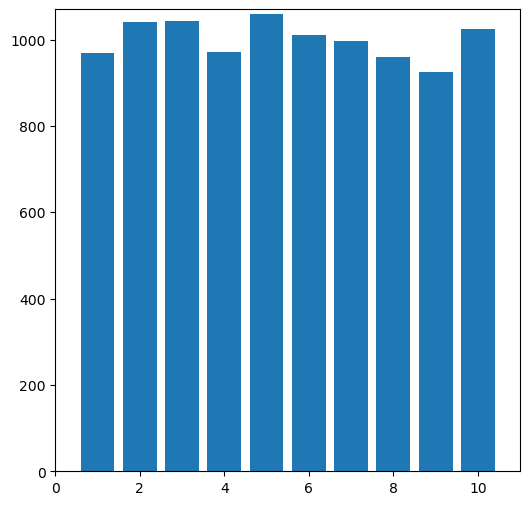

```python
import matplotlib.pyplot as plt

#Xử lí
# Sử dụng hàm np.random.randint để sinh dãy số ngẫu nhiên
a = np.random.randint(1,11,size=10000)
# Sử dụng hàm np.unique để trả về tần số xuất hiện
value, cnt = np.unique(a, return_counts=True)

print("a. Sinh ngẫu nhiên theo phân bố đều")
print(f"+ Gia tri: {value}")
print(f"+ So lan xuat hien: {cnt}")
print("+ Do thi ham so xuat hien")
plt.figure(figsize=(6,6))      #  kich thuoc ban ve
plt.bar(value, cnt)            #  ve cac khoi chu nhat theo day x, y
plt.xlim(0, 11)                #  gioi han truc x
plt.ylim(0, np.max(cnt) + 10)  #  gioi han truc y
plt.savefig("4a.png")          #  luu do thi
plt.show()                     #  hien thi do thi
```

```
b. Sinh cặp (x, y) với y làm hàm phân phối chuẩn
+ x: -4.0 <= min [-3.89] <= max [ 6.00] <= 6.0
+ Ve ham so y(x)
```

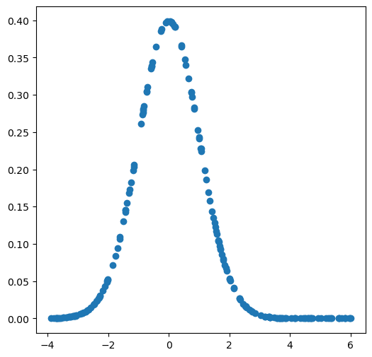

```python
""" CÁC BẠN LÀM BÀI Ở ĐÂY """
# Sử dụm hàm np.random.rand() sinh số ngẫu nhiên trong [0,1) --> [0,1) * (b - a) + a --> [a, b)
# Sử dụng hàm sau để tính hàm xác suất chuẩn N(m, s): np.sqrt, np.exp
x_min, x_max = -4.0, 6.0
m, s = 0, 1   # mean = 0, std = 1

# Sinh ngẫu nhiên x trong [x_min, x_max]
N = 200
x = np.random.rand(N) * (x_max - x_min) + x_min

# Hàm phân phối chuẩn N(m, s)
y = (1 / (s * np.sqrt(2 * np.pi))) * np.exp(-((x - m) ** 2) / (2 * s ** 2))

print("b. Sinh cặp (x, y) với y làm hàm phân phối chuẩn")
print(f"+ x: {x_min} <= min [{np.min(x): .2f}] <= max [{np.max(x): .2f}] <= {x_max}")
print(f"+ Ve ham so y(x)")
plt.figure(figsize=(6,6))      # kich thuoc ban ve
plt.scatter(x, y)              # ve cac diem (xi, yi)
plt.savefig("4b.png")          #  luu do thi
plt.show()                     #  hien thi do thi
```

```
c. Sinh day so theo phan phoi chuan
+ x: len = 100000, min [-3.089388555073917], max [5.738795844833184]
+ Mat so xac suat cua day so x
```

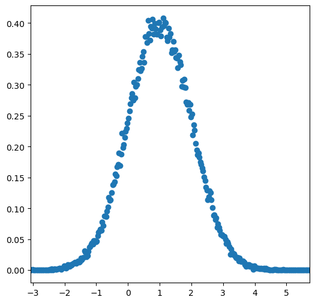

```python
""" CÁC BẠN LÀM BÀI Ở ĐÂY """
m, s = 1, 1     # mean = 1, std = 1
N = 100000      # số lượng mẫu

# Sinh dữ liệu N(m, s^2)
x = m + np.random.randn(N) * s

# Tính histogram với mật số xác suất
cnt, edges = np.histogram(x, bins=300, density=True)

# Tính tâm của mỗi bin
val = (edges[:-1] + edges[1:]) / 2

print( "c. Sinh day so theo phan phoi chuan")
print(f"+ x: len = {len(x)}, min [{np.min(x)}], max [{np.max(x)}]")
print(f"+ Mat so xac suat cua day so x")
plt.figure(figsize=(6,6))      # kich thuoc ban ve
plt.xlim(np.min(val), np.max(val))
plt.scatter(val, cnt)
plt.show()
```

### Bài 2. Tính toán trên ma trận

#### 1. Tạo ma trận a có M = 6 dòng, N = 4 cột

##### Bài làm:

```python
import numpy as np
# a = np.random.randint(100, 200, (6, 4))
#Xử lí
a = np.random.randint(100, 200, (6, 4))

print("Ma trận a: \n", a)
```

```
Ma trận a:
 [[157 169 138 186]
 [184 111 121 178]
 [196 131 121 141]
 [150 160 141 165]
 [128 137 136 191]
 [194 185 106 119]]
```

#### 2. Các thao tác trên ma trận a

(a) In ra ma trận chuyển vị  
(b) In ra phần tử ở vị trí dòng 2 cột 3  
(c) Trích xuất dòng đầu, dòng cuối, dòng 2  
(d) Trích xuất cột kế cuối, cột đầu  
(e) Đảo các giá trị trên từng cột  
(f) Tính tổng các dòng, trung bình các cột <br/ >

##### Bài làm:

```python
#Xử lí
# a. Ma trận chuyển vị
a_t = a.T
# b. Phần tử ở dòng 2, cột 3 (chỉ số bắt đầu từ 0 -> tức là a[1, 2])
v_23 = a[1, 2]
# c. Trích xuất các dòng
d_0 = a[0]        # dòng đầu
d_last = a[-1]    # dòng cuối
d_2 = a[1]        # dòng thứ hai
# d. Trích xuất các cột
c_l1 = a[:, -2]   # cột kế cuối
c_0 = a[:, 0]     # cột đầu
# e. Đảo các giá trị trên từng cột (lật ngược ma trận theo dòng)
dao_cot = a[::-1, :]
# f. Phép tính theo trục
tong_dong = a.sum(axis=1)
tb_cot = a.mean(axis=0)
print(f"a. In ra ma trận chuyển vị: \n{a_t}")
print(f"\nb. In ra phần tử ở vị trí dòng 2 cột 3: {v_23}")
print(f"\nc. Trích xuất các dòng: ")
print(f"   + Dòng đầu : {d_0}")
print(f"   + Dòng cuối: {d_last}")
print(f"   + Dòng hai : {d_2}")
print(f"\nd. Trích xuất các cột: ")
print(f"   + Cột kế cuối: {c_l1}")
print(f"   + Cột đầu: {c_0}")
print(f"\ne. Đảo các giá trị trên từng cột: \n {dao_cot}")
print(f"\nf. Phép tính theo trục:")
print(f"   + Tổng dòng: {tong_dong}")
print(f"   + Trung bình cột: {tb_cot}")
```

```
a. In ra ma trận chuyển vị:
[[157 184 196 150 128 194]
 [169 111 131 160 137 185]
 [138 121 121 141 136 106]
 [186 178 141 165 191 119]]

b. In ra phần tử ở vị trí dòng 2 cột 3: 121

c. Trích xuất các dòng:
   + Dòng đầu : [157 169 138 186]
   + Dòng cuối: [194 185 106 119]
   + Dòng hai : [184 111 121 178]

d. Trích xuất các cột:
   + Cột kế cuối: [138 121 121 141 136 106]
   + Cột đầu: [157 184 196 150 128 194]

e. Đảo các giá trị trên từng cột:
 [[194 185 106 119]
 [128 137 136 191]
 [150 160 141 165]
 [196 131 121 141]
 [184 111 121 178]
 [157 169 138 186]]

f. Phép tính theo trục:
   + Tổng dòng: [650 594 589 616 592 604]
   + Trung bình cột: [168.16666667 148.83333333 127.16666667 163.33333333]
```

#### 3. Các toán tử trên hai ma trận

(a) Tạo hai ma trận A và B có 4 dòng x 3 cột và X có 3 dòng x 4 cột  
(b) Tính tổng, hiệu, tích của từng phần tử trên hai ma trận A và B  
(c) Tính phép nhân ma trận Y = A x X

##### Bài làm:

```python
import numpy as np

# (a) Khai báo các ma trận
A = np.array([
    [2, 3, 3],
    [2, 3, 2],
    [4, 2, 2],
    [1, 2, 5]
])

B = np.array([
    [4, 4, 4],
    [4, 4, 3],
    [5, 3, 1],
    [1, 2, 4]
])

X = np.array([
    [5, 4, 1, 4],
    [3, 4, 1, 2],
    [3, 2, 4, 4]
])

# (b) Các toán tử trên ma trận A và B
AB_add = A + B
AB_sub = A - B
AB_mul = A * B   # tích phần tử

# (c) Nhân ma trận
Y = A.dot(X)

print("a. Tạo hai ma trận A và B có 4 dòng x 3 cột và X có 3 dòng x 4 cột")
print(f"+ Ma tran A: \n{A}")
print(f"+ Ma tran B: \n{B}")
print(f"+ Ma tran X: \n{X}")

print("\nb. Tính tổng, hiệu, tích của từng phần tử trên hai ma trận A và B")
print(f"A + B = \n{AB_add}")
print(f"A - B = \n{AB_sub}")
print(f"A . B = \n{AB_mul}")

print("\nc. Tính phép nhân ma trận Y = A x X")
print(f"Y = A x X --> shape A ({A.shape}) x shape X ({X.shape}) = shape Y ({Y.shape}) \n{Y}")
```

```
a. Tạo hai ma trận A và B có 4 dòng x 3 cột và X có 3 dòng x 4 cột
+ Ma tran A:
[[2 3 3]
 [2 3 2]
 [4 2 2]
 [1 2 5]]
+ Ma tran B:
[[4 4 4]
 [4 4 3]
 [5 3 1]
 [1 2 4]]
+ Ma tran X:
[[5 4 1 4]
 [3 4 1 2]
 [3 2 4 4]]

b. Tính tổng, hiệu, tích của từng phần tử trên hai ma trận A và B
A + B =
[[6 7 7]
 [6 7 5]
 [9 5 3]
 [2 4 9]]
A - B =
[[-2 -1 -1]
 [-2 -1 -1]
 [-1 -1  1]
 [ 0  0  1]]
A . B =
[[ 8 12 12]
 [ 8 12  6]
 [20  6  2]
 [ 1  4 20]]

c. Tính phép nhân ma trận Y = A x X
Y = A x X --> shape A ((4, 3)) x shape X ((3, 4)) = shape Y ((4, 4))
[[28 26 17 26]
 [25 24 13 22]
 [32 28 14 28]
 [26 22 23 28]]
```

#### 4. Giải hệ phương trình tuyến tính

Giải hệ phương trình tuyến tính sau: $$ \left\{\begin{matrix} 4x_1 + 3x_2 - 5x_3 = 2 \\ -2x_1 - 4x_2 + 5x_3 = 5 \\ 8x_1 + 8x_2 = -3 \\ \end{matrix}\right. $$

##### Bài làm:

```python
import numpy as np

# Ma trận A (3x3) và vector y (3x1)
A = np.array([
    [4, 3, -5],
    [-2, -4, 5],
    [8, 8, 0]
])

y = np.array([2, 5, -3])

# Giải hệ phương trình Ax = y
x = np.linalg.solve(A, y)

# Kiểm tra lại: yy = A @ x
yy = A.dot(x)

# Chuẩn sai số ||yy - y||_2
diff = np.linalg.norm(yy - y, 2)

print(f"+ Ma tran A: \n{A}")
print(f"+ Vector y: {y}")
print(f"+ Nghiem x: {x}")
print(f"+ Kiem tra: yy = Ax = {yy} ==> ||yy -y ||_2 = {diff: .2f}")
```

```
+ Ma tran A:
[[ 4  3 -5]
 [-2 -4  5]
 [ 8  8  0]]
+ Vector y: [ 2  5 -3]
+ Nghiem x: [ 2.20833333 -2.58333333 -0.18333333]
+ Kiem tra: yy = Ax = [ 2.  5. -3.] ==> ||yy -y ||_2 =  0.00
```

## Bài tập áp dụng

### Bài 3. Tính gần đúng số pi dùng phương pháp Monte Carlo

Vẽ một đường tròn $C$ có bán kính $r$ nội tiếp một hình vuông $C$, và đặt ngẫu nhiên $N$ chấm lên hình vuông. Tỉ lệ các chấm nằm trong hình tròn trên tổng số chấm xấp xỉ bằng diện tích của hình tròn chia cho hình vuông như sau: $$ \frac{N_C}{N} \approx \frac{\mathbb{S}_C}{\mathbb{S}_N} $$ nơi mà $N_C$ là các chấm trong hình tròn, $N$ là tổng số chấm, $\mathbb{S}_C$ và $\mathbb{S}_N$ lần lượt là diện tích của hình tròn và hình vuông. $$ \mathbb{S}_C = \pi * r^2 $$ $$ \mathbb{S}_N = (2*r)^2 = 4r^2 $$ Do đó, công thức trên trở thành: $$ \frac{N_C}{N} \approx \frac{\pi * r^2}{4r^2} = \frac{\pi}{4} $$ Suy ra, ta có giá trị số $\pi$ được tính như sau: $$ \pi \approx \frac{4N_C}{N} $$

Các bạn hãy lập trình tính sấp xỉ số $\pi$ dùng phương pháp Monte Carlo. Cho biết các sai số với $N = 100$, $N = 10000$, và $N = 1000000$. Vẽ đồ thị minh họa cho chương trình.

**Hướng dẫn**: Viết chương trình phát sinh $N$ điểm $(x_i, y_i)$ với $x_i, y_i \in [-1, -1]$. $(x_i, y_i)$ thuộc hình tròn tâm $(0, 0)$ bán kính 1 nội tiếp hình vuông có tâm tại $(0, 0)$ độ dài cạnh 2 khi và chỉ khi $x_i^2 + y_i^2 <= 1$.

##### Bài làm:

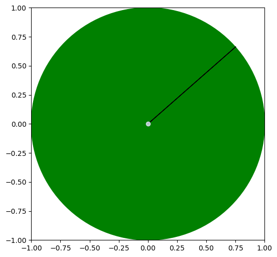

```python
import matplotlib.pyplot as plt # khai báo thư viện vẽ pyplot
import math

circle = plt.Circle((0, 0), 1, color='g') # tạo đối tượng vòng tròn

fig, ax = plt.subplots(figsize=(6, 6)) # lấy figure và vùng vẽ

plt.plot(0, 0, 'o', color=(0.9, 0.9, 1.0), alpha=0.8) # vẽ điểm tại tâm (0,0)
ax.add_patch(circle) # thêm vòng tròn vào vùng vẽ

x = 0.75; y = math.sqrt(1 - (x ** 2)) # (x = 0.75, y = căn bậc 2 của 1 - x^2)
plt.arrow(0, 0, x, y)

plt.xlim(-1, 1) # giới hạn trục x
plt.ylim(-1, 1) # giới hạn trục y

plt.savefig('pi.png') # lưu đồ thị xuống tập tin
plt.show()            # hiển thị đồ thị
```

```python
import numpy as np

def calc_pi_monte_carlo(n = 100):

    x = np.random.uniform(-1, 1, n)
    y = np.random.uniform(-1, 1, n)
    inside_circle = (x**2 + y**2) <= 1

    pi = 4 * np.sum(inside_circle) / n

    return pi
# calc_pi_monte_carlo
```

```python
import math

print("epsilon(n=100): ", calc_pi_monte_carlo(n = 100) - math.pi)
print("epsilon(n=100): ", calc_pi_monte_carlo(n = 100) - math.pi)
print("epsilon(n=10000): ", calc_pi_monte_carlo(n = 10000) - math.pi)
print("epsilon(n=10000): ", calc_pi_monte_carlo(n = 10000) - math.pi)
print("epsilon(n=1000000): ", calc_pi_monte_carlo(n = 1000000) - math.pi)
print("epsilon(n=1000000): ", calc_pi_monte_carlo(n = 1000000) - math.pi)
```

```
epsilon(n=100):  0.33840734641020687
epsilon(n=100):  -0.18159265358979315
epsilon(n=10000):  0.004407346410206792
epsilon(n=10000):  -0.005992653589792951
epsilon(n=1000000):  0.0005073464102069991
epsilon(n=1000000):  1.934641020673311e-05
```

## END

```python
!jupyter nbconvert --to html exercise_code.ipynb
```

[output not shown]

[output cut: 135 more lines]

[output not shown]

[output not shown]